# Pokemon Exploratory Data Analysis

This is the statistical analysis of Pokemon from Gen 1-6. This dataset is taken from kaggle is clean as it is not of any real occurance.

## Importing Dataset

```python
import pandas as pd
import matplotlib.pyplot as plt
import numpy as np
import seaborn as sns
```

```python
pip install opendatasets --upgrade
```

```python
import opendatasets as od
dataset_url = 'https://www.kaggle.com/datasets/mlomuscio/pokemon'
od.download(dataset_url)
```

```
Skipping, found downloaded files in "./pokemon" (use force=True to force download)
```

## Reading the Data

```python
file='./pokemon/PokemonData.csv'
```

```python
df=pd.read_csv(file)
```

```python
print(df)
```

```
     Num                   Name    Type1   Type2  HP  Attack  Defense  SpAtk  \
0      1              Bulbasaur    Grass  Poison  45      49       49     65
1      2                Ivysaur    Grass  Poison  60      62       63     80
2      3               Venusaur    Grass  Poison  80      82       83    100
3      3  VenusaurMega Venusaur    Grass  Poison  80     100      123    122
4      4             Charmander     Fire     NaN  39      52       43     60
..   ...                    ...      ...     ...  ..     ...      ...    ...
795  719                Diancie     Rock   Fairy  50     100      150    100
796  719    DiancieMega Diancie     Rock   Fairy  50     160      110    160
797  720    HoopaHoopa Confined  Psychic   Ghost  80     110       60    150
798  720     HoopaHoopa Unbound  Psychic    Dark  80     160       60    170
799  721              Volcanion     Fire   Water  80     110      120    130

     SpDef  Speed  Generation  Legendary
0       65     45           1      False
1       80     60           1      False
2      100     80           1      False
3      120     80           1      False
4       50     65           1      False
..     ...    ...         ...        ...
795    150     50           6       True
796    110    110           6       True
797    130     70           6       True
798    130     80           6       True
799     90     70           6       True

[800 rows x 12 columns]
```

## Analysis of Gen 1

```python
gen1=df[df['Generation']==1]
```

### Analysis of Fire Types

All the fire types from Gen 1 are showcased below.

```python
fire1=gen1[(gen1['Type1'] == 'Fire') | (gen1['Type2'] == 'Fire')]
```

```python
fire1
```

|  | Num | Name | Type1 | Type2 | HP | Attack | Defense | SpAtk | SpDef | Speed | Generation | Legendary |
| --- | --- | --- | --- | --- | --- | --- | --- | --- | --- | --- | --- | --- |
| 4 | 4 | Charmander | Fire | NaN | 39 | 52 | 43 | 60 | 50 | 65 | 1 | False |
| 5 | 5 | Charmeleon | Fire | NaN | 58 | 64 | 58 | 80 | 65 | 80 | 1 | False |
| 6 | 6 | Charizard | Fire | Flying | 78 | 84 | 78 | 109 | 85 | 100 | 1 | False |
| 7 | 6 | CharizardMega Charizard X | Fire | Dragon | 78 | 130 | 111 | 130 | 85 | 100 | 1 | False |
| 8 | 6 | CharizardMega Charizard Y | Fire | Flying | 78 | 104 | 78 | 159 | 115 | 100 | 1 | False |
| 42 | 37 | Vulpix | Fire | NaN | 38 | 41 | 40 | 50 | 65 | 65 | 1 | False |
| 43 | 38 | Ninetales | Fire | NaN | 73 | 76 | 75 | 81 | 100 | 100 | 1 | False |
| 63 | 58 | Growlithe | Fire | NaN | 55 | 70 | 45 | 70 | 50 | 60 | 1 | False |
| 64 | 59 | Arcanine | Fire | NaN | 90 | 110 | 80 | 100 | 80 | 95 | 1 | False |
| 83 | 77 | Ponyta | Fire | NaN | 50 | 85 | 55 | 65 | 65 | 90 | 1 | False |
| 84 | 78 | Rapidash | Fire | NaN | 65 | 100 | 70 | 80 | 80 | 105 | 1 | False |
| 135 | 126 | Magmar | Fire | NaN | 65 | 95 | 57 | 100 | 85 | 93 | 1 | False |
| 147 | 136 | Flareon | Fire | NaN | 65 | 130 | 60 | 95 | 110 | 65 | 1 | False |
| 158 | 146 | Moltres | Fire | Flying | 90 | 100 | 90 | 125 | 85 | 90 | 1 | True |

A barplot of the speeds of each of them.

[figure not shown]

```python
sns.barplot(x='Name',y='Speed',data=fire1,color='red')
plt.xticks(rotation=45, ha='right')  # Adjust rotation and alignment
plt.show()
```

A barplot of the attack of each of them.

[figure not shown]

```python
sns.barplot(x='Name',y='Attack',data=fire1,color='red')
plt.xticks(rotation=45, ha='right')  # Adjust rotation and alignment
plt.show()
```

A barplot of the defense of each of them.

[figure not shown]

```python
sns.barplot(x='Name',y='Defense',data=fire1,color='red')
plt.xticks(rotation=45, ha='right')  # Adjust rotation and alignment
plt.show()
```

Average values of the stats of the fire type pokemon.

```python
fire1_avg=fire1.describe()
fire1_avg
```

|  | Num | HP | Attack | Defense | SpAtk | SpDef | Speed | Generation |
| --- | --- | --- | --- | --- | --- | --- | --- | --- |
| count | 14.000000 | 14.000000 | 14.000000 | 14.000000 | 14.000000 | 14.000000 | 14.000000 | 14.0 |
| mean | 55.857143 | 65.857143 | 88.642857 | 67.142857 | 93.142857 | 80.000000 | 86.285714 | 1.0 |
| std | 51.011096 | 16.617216 | 26.563732 | 19.829493 | 30.178589 | 19.806759 | 16.030877 | 0.0 |
| min | 4.000000 | 38.000000 | 41.000000 | 40.000000 | 50.000000 | 50.000000 | 60.000000 | 1.0 |
| 25% | 6.000000 | 55.750000 | 71.500000 | 55.500000 | 72.500000 | 65.000000 | 68.750000 | 1.0 |
| 50% | 48.000000 | 65.000000 | 90.000000 | 65.000000 | 88.000000 | 82.500000 | 91.500000 | 1.0 |
| 75% | 77.750000 | 78.000000 | 103.000000 | 78.000000 | 106.750000 | 85.000000 | 100.000000 | 1.0 |
| max | 146.000000 | 90.000000 | 130.000000 | 111.000000 | 159.000000 | 115.000000 | 105.000000 | 1.0 |

```python
fire1_numeric = fire1.select_dtypes(include=['number'])
fire1_numeric
```

|  | Num | HP | Attack | Defense | SpAtk | SpDef | Speed | Generation |
| --- | --- | --- | --- | --- | --- | --- | --- | --- |
| 4 | 4 | 39 | 52 | 43 | 60 | 50 | 65 | 1 |
| 5 | 5 | 58 | 64 | 58 | 80 | 65 | 80 | 1 |
| 6 | 6 | 78 | 84 | 78 | 109 | 85 | 100 | 1 |
| 7 | 6 | 78 | 130 | 111 | 130 | 85 | 100 | 1 |
| 8 | 6 | 78 | 104 | 78 | 159 | 115 | 100 | 1 |
| 42 | 37 | 38 | 41 | 40 | 50 | 65 | 65 | 1 |
| 43 | 38 | 73 | 76 | 75 | 81 | 100 | 100 | 1 |
| 63 | 58 | 55 | 70 | 45 | 70 | 50 | 60 | 1 |
| 64 | 59 | 90 | 110 | 80 | 100 | 80 | 95 | 1 |
| 83 | 77 | 50 | 85 | 55 | 65 | 65 | 90 | 1 |
| 84 | 78 | 65 | 100 | 70 | 80 | 80 | 105 | 1 |
| 135 | 126 | 65 | 95 | 57 | 100 | 85 | 93 | 1 |
| 147 | 136 | 65 | 130 | 60 | 95 | 110 | 65 | 1 |
| 158 | 146 | 90 | 100 | 90 | 125 | 85 | 90 | 1 |

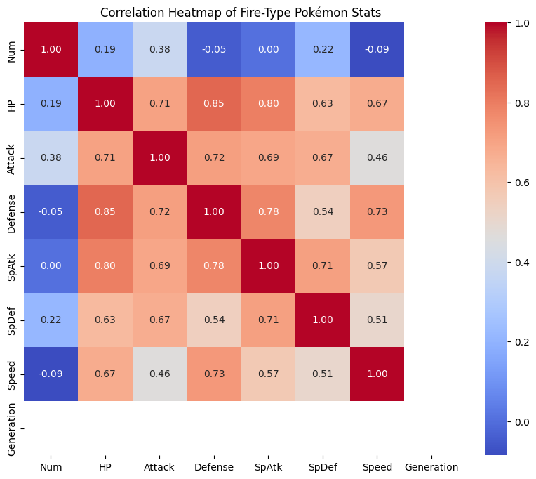

```python
# Calculate the correlation matrix
correlation_matrix = fire1_numeric.corr()

# Plot the heatmap
plt.figure(figsize=(10, 8))
sns.heatmap(correlation_matrix,annot=True, cmap='coolwarm', fmt=".2f", cbar=True)

# Add a title
plt.title('Correlation Heatmap of Fire-Type Pokémon Stats')
plt.show()
```

Plotting all the stats in a barplot along with the average values for better comparison.

[figure not shown]

```python
import pandas as pd
import seaborn as sns
import matplotlib.pyplot as plt



# Step 2: Calculate the average stats
# Get the averages for numerical stats
fire1_avg = fire1[['HP', 'Attack', 'Defense', 'SpAtk', 'SpDef', 'Speed']].mean()

# Step 3: Prepare the data for plotting
# Melt the original data to long format
fire1_melted = fire1.melt(
    id_vars=['Name'],
    value_vars=['HP', 'Attack', 'Defense', 'SpAtk', 'SpDef', 'Speed'],
    var_name='Stat',
    value_name='Value'
)

# Add a row for the averages
avg_rows = pd.DataFrame({
    'Name': ['Average'] * len(fire1_avg),
    'Stat': fire1_avg.index,
    'Value': fire1_avg.values
})

# Combine the original and average data
fire1_comparison = pd.concat([fire1_melted, avg_rows], ignore_index=True)

# Step 4: Plot the comparison
plt.figure(figsize=(14, 8))
sns.barplot(
    data=fire1_comparison,
    x='Name',
    y='Value',
    hue='Stat',
    palette='Set2'
)

# Customize the plot
plt.xticks(rotation=45, ha='right')
plt.title('Comparison of Fire-Type Pokémon Stats with Averages (Generation 1)')
plt.ylabel('Stat Value')
plt.xlabel('Pokémon Name')
plt.legend(title='Stat')
plt.tight_layout()
plt.show()
```

```
Write the name of fire type pokemon from Gen 1: Ninetales
```

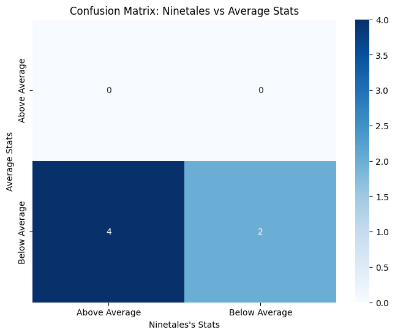

```python
import pandas as pd
import seaborn as sns
import matplotlib.pyplot as plt
from sklearn.metrics import confusion_matrix



# Step 2: Select a specific Pokémon and calculate averages
specific_pokemon_name = input("Write the name of fire type pokemon from Gen 1: ")
specific_pokemon = fire1[fire1['Name'] == specific_pokemon_name].iloc[0]
fire1_avg = fire1[['HP', 'Attack', 'Defense', 'SpAtk', 'SpDef', 'Speed']].mean()

# Step 3: Create labels for "Above Average" or "Below Average"
comparison_data = pd.DataFrame({
    'Stat': ['HP', 'Attack', 'Defense', 'Sp. Atk', 'Sp. Def', 'Speed'],
    'Specific_Pokemon': specific_pokemon[['HP', 'Attack', 'Defense', 'SpAtk', 'SpDef', 'Speed']].values,
    'Average': fire1_avg.values
})

# Assign categories
comparison_data['Specific_Pokemon_Label'] = comparison_data['Specific_Pokemon'] > comparison_data['Average']
comparison_data['Average_Label'] = comparison_data['Average'] > comparison_data['Average']  # Always False

# Map to categories
comparison_data['Specific_Pokemon_Label'] = comparison_data['Specific_Pokemon_Label'].map({True: "Above Average", False: "Below Average"})
comparison_data['Average_Label'] = comparison_data['Average_Label'].map({True: "Above Average", False: "Below Average"})

# Step 4: Build the confusion matrix
conf_matrix = confusion_matrix(
    comparison_data['Average_Label'],
    comparison_data['Specific_Pokemon_Label'],
    labels=["Above Average", "Below Average"]
)

# Step 5: Visualize the confusion matrix with the Pokémon's name on the axis
plt.figure(figsize=(8, 6))
sns.heatmap(
    conf_matrix,
    annot=True,
    fmt="d",
    cmap="Blues",
    xticklabels=["Above Average", "Below Average"],
    yticklabels=["Above Average", "Below Average"]
)

plt.title(f"Confusion Matrix: {specific_pokemon_name} vs Average Stats")
plt.xlabel(f"{specific_pokemon_name}'s Stats")
plt.ylabel("Average Stats")
plt.show()
```

```
Write the name of fire type pokemon from Gen 1: Arcanine
```

[figure not shown]

```python
specific_pokemon_name = input("Write the name of fire type pokemon from Gen 1: ")
specific_pokemon = fire1[fire1['Name'] == specific_pokemon_name].iloc[0]
fire1_avg = fire1[['HP', 'Attack', 'Defense', 'SpAtk', 'SpDef', 'Speed']].mean()

# Create the confusion matrix values (stat/average ratio)
comparison_matrix = pd.DataFrame({
    'Stat': ['HP', 'Attack', 'Defense', 'Sp. Atk', 'Sp. Def', 'Speed'],
    specific_pokemon_name: specific_pokemon[['HP', 'Attack', 'Defense', 'SpAtk', 'SpDef', 'Speed']].values,
    'Average': fire1_avg.values
})

# Calculate the ratio of stats to average
comparison_matrix['Ratio'] = comparison_matrix[specific_pokemon_name] / comparison_matrix['Average']

# Convert to matrix format for plotting
conf_matrix = comparison_matrix.pivot_table(
    values='Ratio',
    index='Stat',
    columns=specific_pokemon_name
)

# Plot the confusion matrix
plt.figure(figsize=(8, 6))
sns.heatmap(
    conf_matrix.astype(float),  # Ensure numerical data
    annot=True,
    fmt=".2f",
    cmap="coolwarm",
    linewidths=0.5
)

# Customize the plot
plt.title(f"Stat Comparison: {specific_pokemon_name} vs Average Stats")
plt.xlabel(f"{specific_pokemon_name}'s Stats")
plt.ylabel("Stat Categories")
plt.tight_layout()
plt.show()
```

In similar manner, all the other types can be analyzed and specific pokemon can be taken to check stats vs the average stats of all the pokemon within that type in a generation.

## Analysis of all Fire Types

```python
fire=df[(df['Type1'] == 'Fire') | (df['Type2'] == 'Fire')]
```

```python
fire
```

|  | Num | Name | Type1 | Type2 | HP | Attack | Defense | SpAtk | SpDef | Speed | Generation | Legendary |
| --- | --- | --- | --- | --- | --- | --- | --- | --- | --- | --- | --- | --- |
| 4 | 4 | Charmander | Fire | NaN | 39 | 52 | 43 | 60 | 50 | 65 | 1 | False |
| 5 | 5 | Charmeleon | Fire | NaN | 58 | 64 | 58 | 80 | 65 | 80 | 1 | False |
| 6 | 6 | Charizard | Fire | Flying | 78 | 84 | 78 | 109 | 85 | 100 | 1 | False |
| 7 | 6 | CharizardMega Charizard X | Fire | Dragon | 78 | 130 | 111 | 130 | 85 | 100 | 1 | False |
| 8 | 6 | CharizardMega Charizard Y | Fire | Flying | 78 | 104 | 78 | 159 | 115 | 100 | 1 | False |
| ... | ... | ... | ... | ... | ... | ... | ... | ... | ... | ... | ... | ... |
| 730 | 662 | Fletchinder | Fire | Flying | 62 | 73 | 55 | 56 | 52 | 84 | 6 | False |
| 731 | 663 | Talonflame | Fire | Flying | 78 | 81 | 71 | 74 | 69 | 126 | 6 | False |
| 735 | 667 | Litleo | Fire | Normal | 62 | 50 | 58 | 73 | 54 | 72 | 6 | False |
| 736 | 668 | Pyroar | Fire | Normal | 86 | 68 | 72 | 109 | 66 | 106 | 6 | False |
| 799 | 721 | Volcanion | Fire | Water | 80 | 110 | 120 | 130 | 90 | 70 | 6 | True |

64 rows × 12 columns

### Analysis of all Legendaries

```python
fire_legendaries=fire[fire['Legendary']==True]
```

[figure not shown]

```python
sns.barplot(x='Name',y='Speed',data=fire_legendaries,color='red')
plt.xticks(rotation=45, ha='right')  # Adjust rotation and alignment
plt.show()
```

Showcasing the average stats of Legendary by name with plots

```
Write the name of fire type Legendary: Ho-oh
```

[figure not shown]

```python
specific_pokemon_name = input("Write the name of fire type Legendary: ")
specific_pokemon = fire_legendaries[fire_legendaries['Name'] == specific_pokemon_name].iloc[0]
fire_legendary_avg = fire_legendaries[['HP', 'Attack', 'Defense', 'SpAtk', 'SpDef', 'Speed']].mean()

# Create the confusion matrix values (stat/average ratio)
comparison_matrix = pd.DataFrame({
    'Stat': ['HP', 'Attack', 'Defense', 'Sp. Atk', 'Sp. Def', 'Speed'],
    specific_pokemon_name: specific_pokemon[['HP', 'Attack', 'Defense', 'SpAtk', 'SpDef', 'Speed']].values,
    'Average': fire_legendary_avg.values
})

# Calculate the ratio of stats to average
comparison_matrix['Ratio'] = comparison_matrix[specific_pokemon_name] / comparison_matrix['Average']

# Convert to matrix format for plotting
conf_matrix = comparison_matrix.pivot_table(
    values='Ratio',
    index='Stat',
    columns=specific_pokemon_name
)

# Plot the confusion matrix
plt.figure(figsize=(8, 6))
sns.heatmap(
    conf_matrix.astype(float),  # Ensure numerical data
    annot=True,
    fmt=".2f",
    cmap="coolwarm",
    linewidths=0.5
)

# Customize the plot
plt.title(f"Stat Comparison: {specific_pokemon_name} vs Average Stats")
plt.xlabel(f"{specific_pokemon_name}'s Stats")
plt.ylabel("Stat Categories")
plt.tight_layout()
plt.show()
```

```python
# Calculate the averages for the relevant stats
fire_legendary_avg = fire_legendaries[['HP', 'Attack', 'Defense', 'SpAtk', 'SpDef', 'Speed']].mean()

# Create a new DataFrame with the ratios
fire_legendaries_ratios = fire_legendaries[['HP', 'Attack', 'Defense', 'SpAtk', 'SpDef', 'Speed']].div(fire_legendary_avg)

# Optional: Add back the names or identifiers for readability
fire_legendaries_ratios['Name'] = fire_legendaries['Name']
```

```python
fire_legendaries_ratios
```

|  | HP | Attack | Defense | SpAtk | SpDef | Speed | Name |
| --- | --- | --- | --- | --- | --- | --- | --- |
| 158 | 0.920716 | 0.846561 | 0.846063 | 1.015228 | 0.829268 | 1.018388 | Moltres |
| 263 | 1.176471 | 0.973545 | 0.799060 | 0.730964 | 0.731707 | 1.131542 | Entei |
| 270 | 1.084399 | 1.100529 | 0.846063 | 0.893401 | 1.502439 | 1.018388 | Ho-oh |
| 424 | 1.023018 | 1.523810 | 1.504113 | 1.218274 | 0.878049 | 1.018388 | GroudonPrimal Groudon |
| 542 | 0.930946 | 0.761905 | 0.996475 | 1.055838 | 1.034146 | 0.871287 | Heatran |
| 553 | 1.023018 | 0.846561 | 0.940071 | 0.812183 | 0.975610 | 1.131542 | Victini |
| 706 | 1.023018 | 1.015873 | 0.940071 | 1.218274 | 1.170732 | 1.018388 | Reshiram |
| 799 | 0.818414 | 0.931217 | 1.128085 | 1.055838 | 0.878049 | 0.792079 | Volcanion |

```python
fire_legendaries['Total_Stats'] = fire_legendaries[['HP', 'Attack', 'Defense', 'SpAtk', 'SpDef', 'Speed']].sum(axis=1)
```

```python
fire_legendaries
```

|  | Num | Name | Type1 | Type2 | HP | Attack | Defense | SpAtk | SpDef | Speed | Generation | Legendary | Total_Stats |
| --- | --- | --- | --- | --- | --- | --- | --- | --- | --- | --- | --- | --- | --- |
| 158 | 146 | Moltres | Fire | Flying | 90 | 100 | 90 | 125 | 85 | 90 | 1 | True | 580 |
| 263 | 244 | Entei | Fire | NaN | 115 | 115 | 85 | 90 | 75 | 100 | 2 | True | 580 |
| 270 | 250 | Ho-oh | Fire | Flying | 106 | 130 | 90 | 110 | 154 | 90 | 2 | True | 680 |
| 424 | 383 | GroudonPrimal Groudon | Ground | Fire | 100 | 180 | 160 | 150 | 90 | 90 | 3 | True | 770 |
| 542 | 485 | Heatran | Fire | Steel | 91 | 90 | 106 | 130 | 106 | 77 | 4 | True | 600 |
| 553 | 494 | Victini | Psychic | Fire | 100 | 100 | 100 | 100 | 100 | 100 | 5 | True | 600 |
| 706 | 643 | Reshiram | Dragon | Fire | 100 | 120 | 100 | 150 | 120 | 90 | 5 | True | 680 |
| 799 | 721 | Volcanion | Fire | Water | 80 | 110 | 120 | 130 | 90 | 70 | 6 | True | 600 |

[figure not shown]

```python
sns.barplot(x='Name',y='Total_Stats',data=fire_legendaries,color='red')
plt.xticks(rotation=45, ha='right')  # Adjust rotation and alignment
plt.show()
```

### Analysis of Non Legendaries with good overall stats

```python
fire['Total_Stats'] = fire[['HP', 'Attack', 'Defense', 'SpAtk', 'SpDef', 'Speed']].sum(axis=1)

fire[(fire['Total_Stats']>500) & (fire['Legendary']==False)]
```

|  | Num | Name | Type1 | Type2 | HP | Attack | Defense | SpAtk | SpDef | Speed | Generation | Legendary | Total_Stats |
| --- | --- | --- | --- | --- | --- | --- | --- | --- | --- | --- | --- | --- | --- |
| 6 | 6 | Charizard | Fire | Flying | 78 | 84 | 78 | 109 | 85 | 100 | 1 | False | 534 |
| 7 | 6 | CharizardMega Charizard X | Fire | Dragon | 78 | 130 | 111 | 130 | 85 | 100 | 1 | False | 634 |
| 8 | 6 | CharizardMega Charizard Y | Fire | Flying | 78 | 104 | 78 | 159 | 115 | 100 | 1 | False | 634 |
| 43 | 38 | Ninetales | Fire | NaN | 73 | 76 | 75 | 81 | 100 | 100 | 1 | False | 505 |
| 64 | 59 | Arcanine | Fire | NaN | 90 | 110 | 80 | 100 | 80 | 95 | 1 | False | 555 |
| 147 | 136 | Flareon | Fire | NaN | 65 | 130 | 60 | 95 | 110 | 65 | 1 | False | 525 |
| 171 | 157 | Typhlosion | Fire | NaN | 78 | 84 | 78 | 109 | 85 | 100 | 2 | False | 534 |
| 248 | 229 | HoundoomMega Houndoom | Dark | Fire | 75 | 90 | 90 | 140 | 90 | 115 | 2 | False | 600 |
| 278 | 257 | Blaziken | Fire | Fighting | 80 | 120 | 70 | 110 | 70 | 80 | 3 | False | 530 |
| 279 | 257 | BlazikenMega Blaziken | Fire | Fighting | 80 | 160 | 80 | 130 | 80 | 100 | 3 | False | 630 |
| 354 | 323 | CameruptMega Camerupt | Fire | Ground | 70 | 120 | 100 | 145 | 105 | 20 | 3 | False | 560 |
| 437 | 392 | Infernape | Fire | Fighting | 76 | 104 | 71 | 104 | 71 | 108 | 4 | False | 534 |
| 518 | 467 | Magmortar | Fire | NaN | 75 | 95 | 67 | 125 | 95 | 83 | 4 | False | 540 |
| 532 | 479 | RotomHeat Rotom | Electric | Fire | 50 | 65 | 107 | 105 | 107 | 86 | 4 | False | 520 |
| 559 | 500 | Emboar | Fire | Fighting | 110 | 123 | 65 | 100 | 65 | 65 | 5 | False | 528 |
| 616 | 555 | DarmanitanZen Mode | Fire | Psychic | 105 | 30 | 105 | 140 | 105 | 55 | 5 | False | 540 |
| 670 | 609 | Chandelure | Ghost | Fire | 60 | 55 | 90 | 145 | 90 | 80 | 5 | False | 520 |
| 698 | 637 | Volcarona | Bug | Fire | 85 | 60 | 65 | 135 | 105 | 100 | 5 | False | 550 |
| 723 | 655 | Delphox | Fire | Psychic | 75 | 69 | 72 | 114 | 100 | 104 | 6 | False | 534 |
| 736 | 668 | Pyroar | Fire | Normal | 86 | 68 | 72 | 109 | 66 | 106 | 6 | False | 507 |

## Aanlysis of Psuedo Legendaries

```python
df['Total_Stats'] = df[['HP', 'Attack', 'Defense', 'SpAtk', 'SpDef', 'Speed']].sum(axis=1)
psuedo_legendaries = df[(df['Legendary'] == False) & (df['Total_Stats'] == 600)]
psuedo_legendaries
```

|  | Num | Name | Type1 | Type2 | HP | Attack | Defense | SpAtk | SpDef | Speed | Generation | Legendary | Total_Stats |
| --- | --- | --- | --- | --- | --- | --- | --- | --- | --- | --- | --- | --- | --- |
| 102 | 94 | GengarMega Gengar | Ghost | Poison | 60 | 65 | 80 | 170 | 95 | 130 | 1 | False | 600 |
| 137 | 127 | PinsirMega Pinsir | Bug | Flying | 65 | 155 | 120 | 65 | 90 | 105 | 1 | False | 600 |
| 161 | 149 | Dragonite | Dragon | Flying | 91 | 134 | 95 | 100 | 100 | 80 | 1 | False | 600 |
| 165 | 151 | Mew | Psychic | NaN | 100 | 100 | 100 | 100 | 100 | 100 | 1 | False | 600 |
| 229 | 212 | ScizorMega Scizor | Bug | Steel | 70 | 150 | 140 | 65 | 100 | 75 | 2 | False | 600 |
| 232 | 214 | HeracrossMega Heracross | Bug | Fighting | 80 | 185 | 115 | 40 | 105 | 75 | 2 | False | 600 |
| 248 | 229 | HoundoomMega Houndoom | Dark | Fire | 75 | 90 | 90 | 140 | 90 | 115 | 2 | False | 600 |
| 267 | 248 | Tyranitar | Rock | Dark | 100 | 134 | 110 | 95 | 100 | 61 | 2 | False | 600 |
| 271 | 251 | Celebi | Psychic | Grass | 100 | 100 | 100 | 100 | 100 | 100 | 2 | False | 600 |
| 408 | 373 | Salamence | Dragon | Flying | 95 | 135 | 80 | 110 | 80 | 100 | 3 | False | 600 |
| 412 | 376 | Metagross | Steel | Psychic | 80 | 135 | 130 | 95 | 90 | 70 | 3 | False | 600 |
| 493 | 445 | Garchomp | Dragon | Ground | 108 | 130 | 95 | 80 | 85 | 102 | 4 | False | 600 |
| 546 | 488 | Cresselia | Psychic | NaN | 120 | 70 | 120 | 75 | 130 | 85 | 4 | False | 600 |
| 548 | 490 | Manaphy | Water | NaN | 100 | 100 | 100 | 100 | 100 | 100 | 4 | False | 600 |
| 696 | 635 | Hydreigon | Dark | Dragon | 92 | 105 | 90 | 125 | 90 | 98 | 5 | False | 600 |
| 715 | 648 | MeloettaAria Forme | Normal | Psychic | 100 | 77 | 77 | 128 | 128 | 90 | 5 | False | 600 |
| 716 | 648 | MeloettaPirouette Forme | Normal | Fighting | 100 | 128 | 90 | 77 | 77 | 128 | 5 | False | 600 |
| 717 | 649 | Genesect | Bug | Steel | 71 | 120 | 95 | 120 | 95 | 99 | 5 | False | 600 |
| 776 | 706 | Goodra | Dragon | NaN | 90 | 100 | 70 | 110 | 150 | 80 | 6 | False | 600 |

```
Write the stat: SpAtk
```

[figure not shown]

```python
stat_input=input("Write the stat: ")
sns.barplot(data=psuedo_legendaries,x='Name',y=stat_input,color='cyan')
plt.xticks(rotation=45, ha='right')  # Adjust rotation and alignment
plt.show()
```